title: “PROJECT_COURSERA” author: “Daiane Rodrigues” date: “6 de março de 2019” output: html_document

## Overview

This project is an assignment to the course Practical Machine Learning and it is a part of the Specialization Data Science from Coursera.

The goal of your project is to predict the manner in which they did the exercise. This is the “classe” variable in the training set. You may use any of the other variables to predict with. You should create a report describing how you built your model, how you used cross validation, what you think the expected out of sample error is, and why you made the choices you did. You will also use your prediction model to predict 20 different test cases.

## Cleaning Data Set

Libnames

```r
library(caret)
```

Data set

```r
testing  =  read.csv(url("https://d396qusza40orc.cloudfront.net/predmachlearn/pml-testing.csv"),header=TRUE);
training =  read.csv(url("https://d396qusza40orc.cloudfront.net/predmachlearn/pml-training.csv"),header=TRUE);
```

We can see that we have 160 columns and 19622 rows.

```r
dim(training);
```

```
## [1] 19622   160
```

It is a lot of variables, but when we open the data set we can see that we have many columns that does not contain data, it is blank space (NA). As we can see bellow

```r
str(training)
```

```
## 'data.frame':    19622 obs. of  160 variables:
##  $ X                       : int  1 2 3 4 5 6 7 8 9 10 ...
##  $ user_name               : Factor w/ 6 levels "adelmo","carlitos",..: 2 2 2 2 2 2 2 2 2 2 ...
##  $ raw_timestamp_part_1    : int  1323084231 1323084231 1323084231 1323084232 1323084232 1323084232 1323084232 1323084232 1323084232 1323084232 ...
##  $ raw_timestamp_part_2    : int  788290 808298 820366 120339 196328 304277 368296 440390 484323 484434 ...
##  $ cvtd_timestamp          : Factor w/ 20 levels "02/12/2011 13:32",..: 9 9 9 9 9 9 9 9 9 9 ...
##  $ new_window              : Factor w/ 2 levels "no","yes": 1 1 1 1 1 1 1 1 1 1 ...
##  $ num_window              : int  11 11 11 12 12 12 12 12 12 12 ...
##  $ roll_belt               : num  1.41 1.41 1.42 1.48 1.48 1.45 1.42 1.42 1.43 1.45 ...
##  $ pitch_belt              : num  8.07 8.07 8.07 8.05 8.07 8.06 8.09 8.13 8.16 8.17 ...
##  $ yaw_belt                : num  -94.4 -94.4 -94.4 -94.4 -94.4 -94.4 -94.4 -94.4 -94.4 -94.4 ...
##  $ total_accel_belt        : int  3 3 3 3 3 3 3 3 3 3 ...
##  $ kurtosis_roll_belt      : Factor w/ 397 levels "","-0.016850",..: 1 1 1 1 1 1 1 1 1 1 ...
##  $ kurtosis_picth_belt     : Factor w/ 317 levels "","-0.021887",..: 1 1 1 1 1 1 1 1 1 1 ...
##  $ kurtosis_yaw_belt       : Factor w/ 2 levels "","#DIV/0!": 1 1 1 1 1 1 1 1 1 1 ...
```

[output cut: 86 more lines]

```r
remove = which(colSums(is.na(training)|training=="")>0.85)
training2 = training[,-remove]
```

Because we want to predict the variable class,it does not make sense to keep the data about the people, like the name of them, so we have to remove those variables to

```r
trainingf = training2[,-c(1:7)]
```

Now we hava 53, variable to do the analysis. We have to do the same steps with the test sample.

```r
removet  = which(colSums(is.na(testing)|testing=="")>0.85)
testing2 = testing[,-removet]
testingf = testing2[,-c(1:7)]
dim(testingf)
```

```
## [1] 20 53
```

## Separating sample for train and test

```r
set.seed(217829)
marc =  createDataPartition(trainingf$classe, p = 0.7, list = FALSE)
train = trainingf[marc, ]
test = trainingf[-marc, ]
dim(train)
```

```
## [1] 13737    53
```

```r
dim(test)
```

```
## [1] 5885   53
```

## Analysis

The next step is to do the predictive analysis. We are going to test two differents techniqhes,Random Forest and Boosting (GBM).We are going to use Cross Validation with 5 folds, I choose 5 folds because we learn that with 10 folds, it does not increase the accuracy so much.

Random Forest

```r
trControl  =  trainControl(method="cv", number=5)
modFit_RF =  train(classe ~ .,method="rf",data=train,trControl = trControl,verbose = FALSE)
print(modFit_RF)
```

```
## Random Forest
##
## 13737 samples
##    52 predictor
##     5 classes: 'A', 'B', 'C', 'D', 'E'
##
## No pre-processing
## Resampling: Cross-Validated (5 fold)
## Summary of sample sizes: 10991, 10989, 10990, 10989, 10989
## Resampling results across tuning parameters:
##
##   mtry  Accuracy   Kappa
##    2    0.9897362  0.9870156
##   27    0.9903908  0.9878444
##   52    0.9860957  0.9824114
##
## Accuracy was used to select the optimal model using the largest value.
## The final value used for the model was mtry = 27.
```

We can see how the model is working on the test sample The accuracy of the model is very good

```r
predrf = predict(modFit_RF,test)
res_rf = confusionMatrix(test$classe,predrf)
res_rf
```

```
## Confusion Matrix and Statistics
##
##           Reference
## Prediction    A    B    C    D    E
##          A 1673    1    0    0    0
##          B   10 1128    1    0    0
##          C    0    7 1011    8    0
##          D    0    0    5  958    1
##          E    0    0    2    2 1078
##
## Overall Statistics
##
##                Accuracy : 0.9937
##                  95% CI : (0.9913, 0.9956)
##     No Information Rate : 0.286
##     P-Value [Acc > NIR] : < 2.2e-16
##
##                   Kappa : 0.992
##  Mcnemar's Test P-Value : NA
##
## Statistics by Class:
##
##                      Class: A Class: B Class: C Class: D Class: E
## Sensitivity            0.9941   0.9930   0.9921   0.9897   0.9991
## Specificity            0.9998   0.9977   0.9969   0.9988   0.9992
## Pos Pred Value         0.9994   0.9903   0.9854   0.9938   0.9963
## Neg Pred Value         0.9976   0.9983   0.9984   0.9980   0.9998
## Prevalence             0.2860   0.1930   0.1732   0.1645   0.1833
## Detection Rate         0.2843   0.1917   0.1718   0.1628   0.1832
## Detection Prevalence   0.2845   0.1935   0.1743   0.1638   0.1839
## Balanced Accuracy      0.9969   0.9953   0.9945   0.9942   0.9991
```

```r
res_rf$table
```

```
##           Reference
## Prediction    A    B    C    D    E
##          A 1673    1    0    0    0
##          B   10 1128    1    0    0
##          C    0    7 1011    8    0
##          D    0    0    5  958    1
##          E    0    0    2    2 1078
```

```r
names(modFit_RF$finalModel)
```

```
##  [1] "call"            "type"            "predicted"
##  [4] "err.rate"        "confusion"       "votes"
##  [7] "oob.times"       "classes"         "importance"
## [10] "importanceSD"    "localImportance" "proximity"
## [13] "ntree"           "mtry"            "forest"
## [16] "y"               "test"            "inbag"
## [19] "xNames"          "problemType"     "tuneValue"
## [22] "obsLevels"       "param"
```

we can see that using more than 30 trees does nor decrease the error so much.

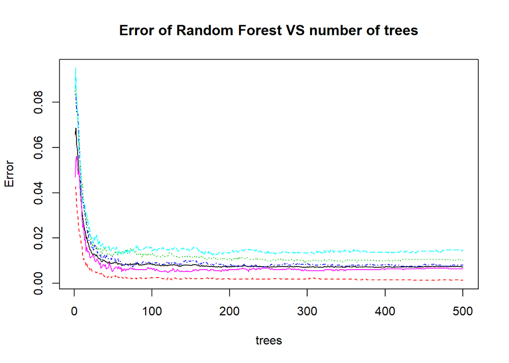

```r
plot(modFit_RF$finalModel,main="Error of Random Forest VS number of trees")
```

We can measure the variables importances.

```r
Mostimport = varImp(modFit_RF)
Mostimport
```

```
## rf variable importance
##
##   only 20 most important variables shown (out of 52)
##
##                      Overall
## roll_belt            100.000
## pitch_forearm         59.228
## yaw_belt              53.360
## pitch_belt            43.332
## roll_forearm          42.045
## magnet_dumbbell_z     41.643
## magnet_dumbbell_y     40.938
## accel_dumbbell_y      19.441
## magnet_dumbbell_x     17.685
## roll_dumbbell         17.528
## accel_forearm_x       16.944
## magnet_belt_z         15.383
## accel_dumbbell_z      13.972
## accel_belt_z          13.651
## magnet_forearm_z      13.306
## yaw_arm               11.982
## magnet_belt_y         11.833
## total_accel_dumbbell  11.759
## magnet_belt_x         10.044
## gyros_belt_z           9.761
```

With Random Forest we get 99.38% of accuracy. This is a satisfatory result.

## Boosting - GBM

```r
modFit_gbm = train(classe~ .,method="gbm",data=train,trControl = trControl,verbose = FALSE)
print(modFit_gbm)
```

```
## Stochastic Gradient Boosting
##
## 13737 samples
##    52 predictor
##     5 classes: 'A', 'B', 'C', 'D', 'E'
##
## No pre-processing
## Resampling: Cross-Validated (5 fold)
## Summary of sample sizes: 10990, 10990, 10989, 10991, 10988
## Resampling results across tuning parameters:
##
##   interaction.depth  n.trees  Accuracy   Kappa
##   1                   50      0.7581729  0.6933235
##   1                  100      0.8218687  0.7744686
##   1                  150      0.8541172  0.8153692
##   2                   50      0.8554271  0.8167957
##   2                  100      0.9067494  0.8819825
##   2                  150      0.9312812  0.9130464
##   3                   50      0.8975761  0.8703533
##   3                  100      0.9437290  0.9287983
##   3                  150      0.9600354  0.9494388
##
## Tuning parameter 'shrinkage' was held constant at a value of 0.1
##
## Tuning parameter 'n.minobsinnode' was held constant at a value of 10
## Accuracy was used to select the optimal model using the largest value.
## The final values used for the model were n.trees = 150,
##  interaction.depth = 3, shrinkage = 0.1 and n.minobsinnode = 10.
```

We can see how the model is working on the test sample The accuracy of the model is good, but the Random Forest is better

```r
predgbm = predict(modFit_gbm,test)
gbm = confusionMatrix(predgbm,test$classe)$overall[1]
res_gbm = confusionMatrix(test$classe,predgbm)
res_gbm
```

```
## Confusion Matrix and Statistics
##
##           Reference
## Prediction    A    B    C    D    E
##          A 1634   26   10    1    3
##          B   35 1077   24    1    2
##          C    0   31  978   16    1
##          D    3    4   39  911    7
##          E    2   15    9   23 1033
##
## Overall Statistics
##
##                Accuracy : 0.9572
##                  95% CI : (0.9517, 0.9622)
##     No Information Rate : 0.2845
##     P-Value [Acc > NIR] : < 2.2e-16
##
##                   Kappa : 0.9458
##  Mcnemar's Test P-Value : 3.016e-07
##
## Statistics by Class:
##
##                      Class: A Class: B Class: C Class: D Class: E
## Sensitivity            0.9761   0.9341   0.9226   0.9569   0.9876
## Specificity            0.9905   0.9869   0.9901   0.9893   0.9899
## Pos Pred Value         0.9761   0.9456   0.9532   0.9450   0.9547
## Neg Pred Value         0.9905   0.9840   0.9831   0.9917   0.9973
## Prevalence             0.2845   0.1959   0.1801   0.1618   0.1777
## Detection Rate         0.2777   0.1830   0.1662   0.1548   0.1755
## Detection Prevalence   0.2845   0.1935   0.1743   0.1638   0.1839
## Balanced Accuracy      0.9833   0.9605   0.9563   0.9731   0.9887
```

```r
res_gbm$table
```

```
##           Reference
## Prediction    A    B    C    D    E
##          A 1634   26   10    1    3
##          B   35 1077   24    1    2
##          C    0   31  978   16    1
##          D    3    4   39  911    7
##          E    2   15    9   23 1033
```

```r
names(modFit_gbm$finalModel)
```

```
##  [1] "initF"             "fit"               "train.error"
##  [4] "valid.error"       "oobag.improve"     "trees"
##  [7] "c.splits"          "bag.fraction"      "distribution"
## [10] "interaction.depth" "n.minobsinnode"    "num.classes"
## [13] "n.trees"           "nTrain"            "train.fraction"
## [16] "response.name"     "shrinkage"         "var.levels"
## [19] "var.monotone"      "var.names"         "var.type"
## [22] "verbose"           "classes"           "estimator"
## [25] "data"              "xNames"            "problemType"
## [28] "tuneValue"         "obsLevels"         "param"
```

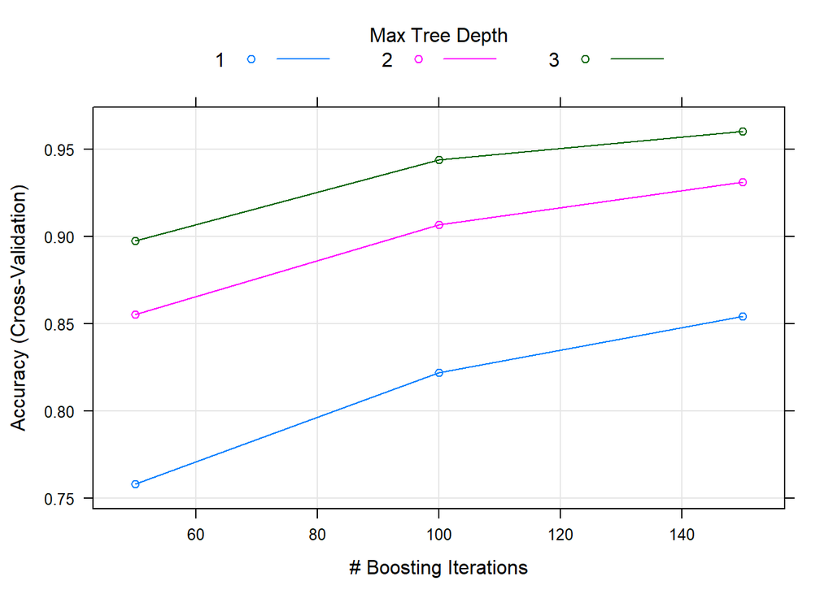

```r
plot(modFit_gbm)
```

## Conclusion

The best model is Random Forest. We are going to apply these model on the test data cleaning

```r
datateste = predict(modFit_RF,testingf)
datateste
```

```
##  [1] B A B A A E D B A A B C B A E E A B B B
## Levels: A B C D E
```